# Curso Matemáticas - Actividad Individual

Mario Estrada Ferreira

2023-05-30

## ¿Qué es una red neuronal?

En tecnología de la información (TI), una red neuronal artificial (RNA) es un sistema de hardware y/o software basado en el funcionamiento de las neuronas del cerebro humano. Las RNA también llamadas, simplemente, redes neuronales- son una variedad de la tecnología de aprendizaje profundo, que también se engloba dentro de la inteligencia artificial o IA.

Las redes neuronales son ampliamente utilizadas en el ámbito de la Inteligencia Artificial. Pueden ser una solución para la mayoría de los problemas de predicción gracias a su escalabilidad y flexibilidad. Puede resolver problemas complejos de regresión, clasificación, predicción, reconocimiento de objetos, reconocimiento de voz, PNL, etc.

## Ejemplos que puedes ser apicados al área de desarrollo de software y analisis de datos

1.- Detección de anomalías en el código fuente: Una red neuronal puede entrenarse para identificar patrones de código anómalos, como vulnerabilidades de seguridad o errores de programación, ayudando así a mejorar la calidad del software.

2.- Clasificación de documentos: Las redes neuronales pueden utilizarse para clasificar automáticamente documentos y archivos según su contenido. Por ejemplo, podrían utilizarse para organizar y etiquetar automáticamente grandes conjuntos de archivos de código fuente.

3.- Extracción de información: Las redes neuronales pueden entrenarse para extraer información relevante de grandes volúmenes de datos no estructurados. Por ejemplo, podrían utilizarse para extraer datos importantes de documentos legales o informes financieros.

4.- Recomendación de código: Una red neuronal puede analizar el código fuente existente y recomendar soluciones o mejoras basadas en patrones identificados en repositorios de código. Esto puede ayudar a los desarrolladores a escribir código más eficiente y de mayor calidad.

5.- Predicción de errores: Mediante el análisis de datos históricos de errores de software, una red neuronal puede predecir la probabilidad de que se produzcan nuevos errores en el código. Esto permite a los desarrolladores centrarse en las áreas de mayor riesgo y priorizar las pruebas y correcciones.

6.- Análisis de sentimientos de usuarios: Las redes neuronales pueden utilizarse para analizar los sentimientos de los usuarios en redes sociales o reseñas de productos. Esto puede ser útil para comprender la satisfacción del cliente y mejorar los productos o servicios ofrecidos.

## Matemáticas involucradas

Las matemáticas detrás de las redes neuronales siguen siendo un misterio y tener los conocimientos matemáticos detrás de las redes neuronales y el aprendizaje profundo puede ayudar a entender lo que está sucediendo dentro de una red neuronal.

Gracias a las capas, cada neurona de una capa está conectada a las neuronas de la capa siguiente. La figura siguiente representa la estructura básica de una red neuronal con tres capas.

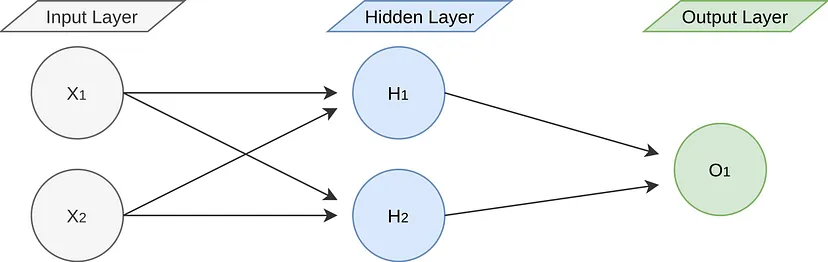

Como puede ver en la figura anterior, hay 3 capas: entrada, oculta y salida. Estas tres capas son las principales de una red neuronal.

Las neuronas de la capa de entrada representan cada variable del conjunto de datos. La neurona de la capa de salida representa el valor final predicho después de que los valores de entrada hayan pasado por todas las neuronas de la capa oculta. Aunque sólo hay una capa de entrada y una de salida, se puede aumentar el número de capas ocultas. Por lo tanto, el rendimiento de las redes neuronales depende del número de capas y del número de neuronas de cada capa. El rendimiento predictivo entre una red con 3 capas ocultas con 3 neuronas en cada capa y una red con una capa-una neurona puede ser diferente.

La figura siguiente muestra una red con 2 capas ocultas.

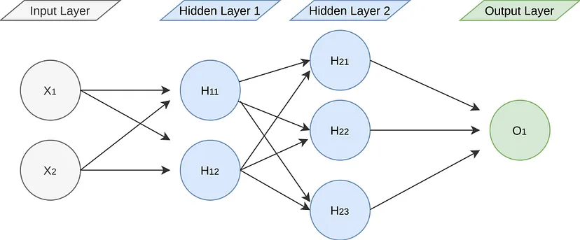

Se pueden añadir más capas ocultas y neuronas a la red. No hay ningún límite para ello. Pero no se debe olvidar que añadir más capas y neuronas no significa que la red vaya a predecir mejor. Sin embargo, cuando se aumenta el número de capas ocultas y neuronas, el tiempo de entrenamiento aumentará debido a los cálculos en cada neurona. Lo que se tiene que hacer es encontrar la mejor estructura de red para la red.

Las redes neuronales funcionan por iteraciones y cada iteración entrena al modelo para alcanzar la mejor predicción. Así pues, alimentar las neuronas es el movimiento principal que entrena nuestra red. Este movimiento se denomina “feed forward” en las redes neuronales. Lo que significa es tomar los datos de las neuronas conectadas anteriormente, hacer cálculos con esos datos y enviar el resultado a las siguientes neuronas conectadas. Cuando se realiza el cálculo final en la neurona de salida, se toma otra observación del conjunto de datos y se vuelve a alimentar. Este proceso continúa hasta que la predicción de nuestra red se acerca mucho al valor real que se ha predicho. Lo más importante aquí es qué cálculos se realizan en las neuronas. Básicamente podemos llamar ponderación a estos cálculos. No se debe olvidar que se hará predicciones utilizando la red. Por lo tanto, se necesita que las neuronas estén ponderadas para hacer la mejor predicción.

Supongamos que tenemos una red neuronal con 1 capa de entrada con 2 neuronas de entrada, 1 capa oculta con 2 neuronas y 1 capa de salida con 1 neurona. Entonces, primero podemos inspeccionar el proceso de alimentación de una neurona en la capa oculta;

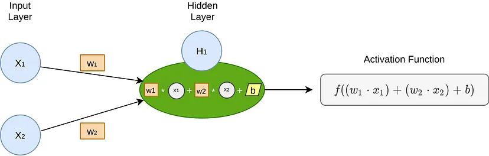

En la figura anterior, hay dos neuronas en la capa de entrada. Significa que tenemos dos variables en nuestro conjunto de datos que vamos a utilizar para el entrenamiento. Como puede ver, cada conexión entre las neuronas de entrada y la neurona de la capa oculta tiene valores “W”. Estos valores “W” representan los valores que una sola neurona mantiene para cada neurona que se alimenta. En el primer paso los valores “W” y “b” pueden generarse aleatoriamente entre 0 y 1. Durante las iteraciones (pasos) estos valores se actualizarán para alcanzar el mejor valor predicho. Veremos estas iteraciones en las siguientes secciones.

Una red neuronal multicapa casi siempre se representa como un diagrama con una red de neuronas, se puede olvidar que es sólo una función matemática.

[figure not shown]

### Funciones de activación

Existen diferentes funciones de activación que se pueden elegir según el valor que se desea predecir. Supongamos que se quiere predecir 2 clases indicadas como 0 y 1. Entonces, lo que se necesita es un valor de probabilidad entre 0 y 1 para decidir la clase predicha. Si el valor predicho es inferior a 0,5 (lo que significa que está próximo a la clase 0) podemos decir que se predice como 0. Si es superior a 0,5 podemos decir que se predice como 1. Pero, sin función de activación es posible obtener valores predichos fuera de 0 y 1. Para solucionar este problema, podemos utilizar una función de activación que mantenga los valores de las neuronas entre 0 y 1. Esta función de activación se denomina “Sigmoidea”.

En la figura siguiente se presentan otras funciones de activación que se utilizan habitualmente.

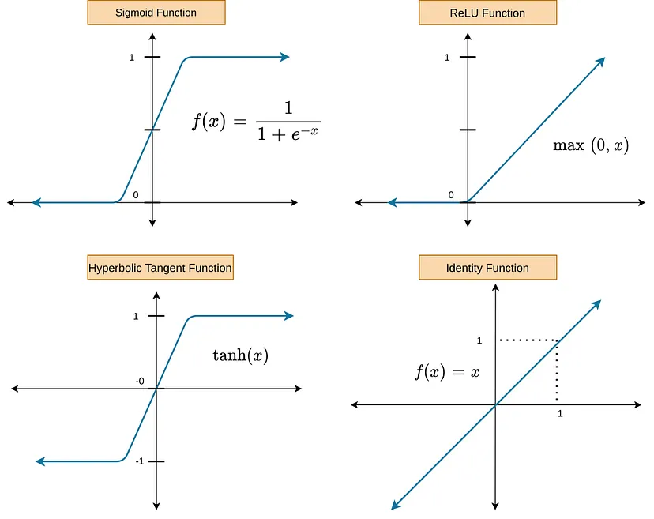

Si nos fijamos en la figura anterior, también hay otras funciones de activación. Por ejemplo, la función tangente hiperbólica se puede utilizar cuando necesitamos una salida entre -1 y 1. La función ReLU se puede utilizar si la salida no debe ser inferior a 0 e identificar la función devuelve la salida como estaba. Esto significa que los valores calculados en las neuronas serán los mismos. Según la variable que se vaya a predecir, se elegirá una de estas funciones.

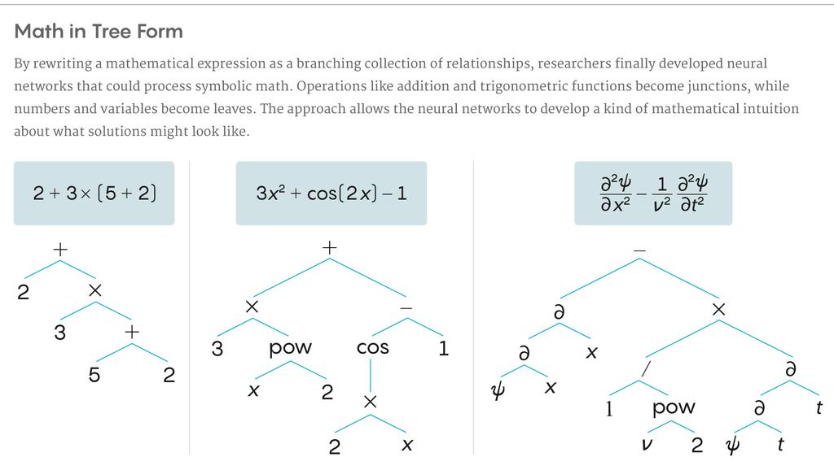

# Desarrollo matematico amplio en el uso de una red neuronal para la predicción de errores en el desarrollo de software

Este problema se puede abordar utilizando técnicas de aprendizaje automático supervisado, donde se entrena una red neuronal con datos históricos de errores en el código y se le proporciona información sobre diferentes características del código fuente. A partir de esta información, la red neuronal puede aprender patrones y correlaciones que le permitan predecir la probabilidad de ocurrencia de errores en nuevas piezas de código.

## Introducción

Se plantea que se tiene un conjunto de datos históricos que contiene información sobre el código fuente de diferentes proyectos de software, así como si ocurrieron errores en el código o no. Cada instancia del conjunto de datos consta de características del código, como el tamaño del archivo, el número de líneas de código y la complejidad ciclomática, junto con una etiqueta binaria indicando si se produjo un error (1) o no (0).

El desarrollo matemático en este caso se enfocará utilizando la arquitectura de la red neuronal feedforward, la selección y preparación de los datos simulados con cierto número de variables y valores, la elección de las funciones de activación y la función de pérdida, así como la optimización de los hiperparámetros del modelo.

Otros de los hiperparámetros que se plantea es el de una tasa de aprendizaje del 0.01 y se podría plantear el entramiento a través de 100 iteraciones que se consideraría el mismo tamaño del lote.

## Arquitectura de la red neuronal

La red neuronal planteada es la feedforward básica el cual dicho tipo de red neuronal se caracteriza por ejecutar el procesamiento de datos en una sola dirección, es una arquitectura fácil de programar y por lo tanto las matemáticas aplicadas en ella son mas convenientes para la problemática que se está abarcando. La red neuronal planteada tendrá dos capas ocultas, teniendo para este caso 2 neuronas en la primera capa oculta y 4 neuronas en la segunda capa oculta; además se tendrá una capa de salida con una neurona.

## Funciones de activación

Las funciones de activación planteadas son:

Paras las capas ocultas:

> ReLU: **ReLU(x) = max(0, x)**

La cual la función max devuelve el valor máximo entre 0 y **“x”** , lo cual significa que si **“x”** es mayor que 0, la función ReLU devuelve **“x”**; de lo contrario, devuelve 0.

Se decidió que esta función de activación es la adecuada debido a términos de rendimiento y entrenamiento para nuestro problema planteado, la no linealidad que se introduce en una red a través de la función permite que las neuronas aprendan relaciones mas complejas en los datos y es más conveniente usarlas en las capas ocultas que no implican una salida final de datos.

Para la capa de salida:

> Sigmoide: **sigmoid(x) = 1 / (1 + exp(-x))**

Donde **“x”** es el valor de entrada a la función y la función exp representa la función exponencial, en esta función se produce una predicción de probabilidad entre 0 y 1, donde los valores cercanos a 0 indican una predicción negativa (sin error) y valores cercanos a 1 indican una predicción positiva (con error).

Esta función de activación fue la adecuada para el planteamiento debido a que se utiliza comúnmente en las redes neuronales para trasformar la salida de una neurona en un valor entre 0 y 1. Existe limitaciones como el desvanecimiento del gradiente y la no simetría alrededor del punto medio, sin embargo, para nuestro caso no implica un riesgo en el uso de esta función.

## Función de perdida

Como nuestro planteamiento es de clasificación binaria es decir que solo esperamos un resultado error o no error en el desarrollo de software se plantea la función de perdida de entropía cruzada binaria. Esta función mide las discrepancias entre las etiquetas reales y las predicciones de la red neuronal.

> **Perdida = -[y * log(y_hat) + (1 - y) * log(1 – y_hat)]**

En donde **“y”** es la etiqueta real u objetivo (0 y 1) que puede entenderse en si hubo error o no en el desarrollo de software de cada iteración; y donde **“y_hat”** es la predicción de la red neuronal, generada en la capa de salida.

## Algoritmo para la optimización

El algoritmo que se plantea utilizar es el algoritmo de descenso de gradientes estocástico, el cual es un algoritmo de optimización para minimizar la perdida de un modelo predictivo con respecto al conjunto de datos que se proporciona para el planteamiento dado. Este algoritmo ayuda a que los modelos aprendan con el tiempo, actuando como un barómetro midiendo su precisión en cada iteración de actualización de parámetros. Este algoritmo se plantea para ajustar los pesos t sesgos de la red neuronal.

> **nuevo_peso = viejo_peso – tasa_aprendizaje * gradiente**
- nuevo_peso es el valor actualizado del peso
- viejo_peso es el valor anterior del peso
- tasa_aprendizaje es la tasa de aprendizaje, que determina que tan grande serna los pasos de actualización
- gradiente es el gradiente del peso, calculado durante la retroprogramación del error.

> **nuevo_sesgo = viejo_sesgo - tasa_aprendizaje * gradiente_sesgo**
- nuevo_sesgo es el valor actualizado del peso
- viejo_sesgo es el valor anterior del peso
- tasa_aprendizaje es la tasa de aprendizaje, que determina que tan grande sera los pasos de actualización
- gradiente_sesgo es el gradiente del peso, calculado durante la retroprogramación del error.

En ambos casos tanto el peso como el sesgo viejo y nuevo representan los pesos y sesgos asociados a las conexiones entre las neuronas de dos capas consecutivas.

El gradiente en ambos casos se refiere a la derivada parcial de la función de perdida con respecto a ese peso o sesgo especifico.

## Algoritmo de retroprogramación del error

El calculo del gradiente implica propagar el error hacia atrás a través de la red neuronal y calcular las derivadas parciales en cada capa para determinar la contribución de cada peso al error total. Se utiliza para poder actualizar los pesos o sesgos en función de si mismo en cada capa.

*1.- Calculo del error en la capa de salida*

> **error_salida = y_hat - y**

En donde **“y”** es la etiqueta real u objetivo (0 y 1) que puede entenderse en si hubo error o no en el desarrollo de software de cada iteración; y donde **“y_hat”** es la predicción de la red neuronal, generada en la capa de salida.

Esta formula para calcular el error en la capa de salida, obteniendo la diferencia entre la etiqueta real y la predicción de la red.

*2.- Retroprogramación del error hacia la capa oculta*

> **error_oculto = error_salida * sigmoid_derivative(activación_salida) * pesos_salida**

Se calcula el error en la capa oculta propagando el error de la capa de salida hacia atrás a través de los pesos que conectan la capa oculta con la capa de salida.

*3.- Calculo de gradientes*

> **salida_pesos_gradiente = error_salida * sigmoid.derivative(activación_salida) * activación_oculta**

La fórmula anterior calcula el gradiente de los pesos que conectan la capa de salida con la capa oculta utilizando el error en la capa de salida y las activaciones en la capa oculta.

> **Oculta_pesos_gradiente = error_oculto * sigmoid.derivative(activación_oculto) * activación_entrada**

La fórmula anterior calcula el gradiente de los pesos que conectan la capa oculta con la capa de entrada utilizando el error en la capa oculta y las activaciones en la capa de entrada.

## Métricas de evaluación

Las métricas de evaluación sirven para una vez terminado el entramiento de la red neuronal se proceda a evaluar el modelo que se ha planteado, para esto se utiliza un conjunto de pruebas separado y se calculan diferentes métricas en este caso la precisión, recall y F1-score.

> **precision = TP / (TP + FP)**

En el cual TP son los resultados verdaderos positivos y FP son los falsos positivos.

Esta métrica mide la proporción de instancias clasificadas como positivas que realmente son positivas y sirve para indicar que tan precisas son las predicciones positivas.

> **recall = TP / (TP + FN)**

En el cual TP son los resultados verdaderos positivos y FN son los falsos negativos.

Esta métrica mide la proporción de instancias positivas que han sido correctamente clasificadas como positivas y sirve para indicar que tan bien el modelo encuentra todos los casos positivos.

> **F1-score = 2 * (precisión * recall) / (precision + recall)**

Donde precision y recall son obtenidas anteriormente con sus respectivas formulas.

Esta métrica combina la precisión y el recall en una única métrica que proporciona un balance entre ambos, siendo una combinación ponderada de ambas métricas.

## Desarrollo del proceso matemático

1.- A partir de los datos simulados para el planteamiento de la creación de un desarrollo matemático para nuestra problemática planteada, se clasifican las características o variables de nuestro conjunto de datos:

- Características de entrada (X):
  - X1: Número de líneas de código normalizado
  - X2: Complejidad ciclomática normalizada
- Etiqueta objetivo (y):
  - 1 si hay un error en el desarrollo de software
  - 0 si no hay errores

Se cuenta con lo valores iniciales de los pesos y sesgos de la red neuronal, estos pueden ser aleatorios al principio, estos deben ser en un rango adecuado.

2.- Se realiza la acción de paso hacia adelante (forward pass)

- Se calcula las activaciones en la primera capa oculta utilizando las características de entrada (X), los pesos y sesgos correspondientes. o Aplicamos la función de activación ReLU a las activaciones en la primera capa oculta.

  **A1 = max(0, suma_ponderada + sesgo)**
- Calculamos las activaciones en la segunda capa oculta utilizando las activaciones de la primera capa oculta, los pesos y sesgos correspondientes. o Aplicamos la función de activación ReLU a las activaciones en la segunda capa oculta.

  **A2 = max(0, suma_ponderada + sesgo)**
- Calculamos la activación en la capa de salida utilizando las activaciones de la segunda capa oculta, los pesos y sesgo correspondientes. o Aplicamos la función de activación sigmoide a la activación en la capa de salida.

  **AP(prediccion) = 1 / (1 + exp(-(suma_ponderada + sesgo)))**

3.- Se realiza el calculo de la perdida a partir del resultado de la salida final de la red neuronal

- Aquí se utiliza la función de pérdida de entropía cruzada binaria

  **Perdida = -(y * log(prediccion) + (1 - y) * log(1 - prediccion))**

  Recordando que **“y”** es la etiqueta objetivo que se planteó al principio

4.- Se realiza la retroprogramación del error y el cálculo de los gradientes

- Se procede a calcular el error en la capa de salida:

  **error = prediccion - y**
- Para cada capa oculta, se calculó el error utilizando el error de la capa siguiente:

  **error = (pesos_siguientes * error_siguiente) * derivada_función_activación(suma_ponderada)**
- Se calculó el gradiente de pesos utilizando el error y la activación de la capa anterior:

  **gradientes_pesos = activación_anterior * error**
- Se calculó el gradiente de sesgo utilizando el error:

  **gradientes_sesgos = error**

5.- Se procede a actualizar los pesos y sesgos a partir de los gradientes obtenidos en el paso anterior

- Se utilizó el algoritmo de descenso de gradientes estocástico con una tasa de aprendizaje del 0.01:

  **nuevos_pesos = pesos_actuales - learning_rate * gradientes_pesos**

  **nuevos_sesgos = sesgos_actuales - learning_rate * gradientes_sesgos**

6.- El proceso se repite de los pasos 2 a 5 que en este caso planteado fue de 100, por lo tanto, el aprendizaje de la red neuronal hasta llegar al resultado final acabaría hasta completar dichas iteraciones.

7.- Se procede a calcular las métricas estipuladas al principio, teniendo en cuenta que para ello se necesita tener un conjunto de datos de prueba adicional para poder evaluar el modelo que se planteó entrenar.

- **precision = TP / (TP + FP)**
- **recall = TP / (TP + FN)**
- **F1-score = 2 * (precisión * recall) / (precision + recall)**

### Referencias

> What is a neural network? Explanation and examples. (2021, marzo). techtarget. https://www.techtarget.com/searchenterpriseai/definition/neural-network

> The Math Behind Training of a Neural Network. (2020,27 de septiembre). towardsdatascience. https://towardsdatascience.com/adventure-of-the-neurons-theory-behind-the-neural-networks-5d19c594ca16

> How To Define A Neural Network as A Mathematical Function. (2022,22 de febrero). towardsdatascience. https://towardsdatascience.com/how-to-define-a-neural-network-as-a-mathematical-function-f7b820cde3f

> Symbolic Mathematics Finally Yields to Neural Networks. (2020,20 de mayo). quantamagazine. https://www.quantamagazine.org/symbolic-mathematics-finally-yields-to-neural-networks-20200520/

> Redes Neuronales. https://ml4a.github.io/ml4a/es/neural_networks/

> Las matemáticas del Machine Learning: Redes Neuronales (Parte I). (2019,26 de noviembre). Fran Ramírez. https://empresas.blogthinkbig.com/las-matematicas-del-machine-learning-redes-neuronales-parte-i/

> Algoritmo de Retropropagacion. Pedro Almagro. http://www.cs.us.es/~fsancho/ficheros/IAML/2016/Sesion04/capitulo_BP.pdf